# Introduction to Linear Regression

Linear Regression Course

2026-01-20

## Learning Objectives

By the end of this lecture, you will be able to:

- Understand the importance of reproducibility in statistical analysis
- Set up a reproducible R workflow using tidyverse
- Perform basic exploratory data analysis
- Understand the concept of linear relationships between variables

## Setup

```r
library(tidyverse)  # Data manipulation and visualization
library(broom)      # Tidy model outputs
library(car)        # Regression diagnostics

# Set default ggplot theme
theme_set(theme_minimal())

# Set seed for reproducibility
set.seed(123)
```

## What is Reproducibility?

**Reproducibility** means that someone else (including future you!) can:

1. Obtain the same data
2. Run the same code
3. Get the same results

### Why Does It Matter?

- **Science**: Results must be verifiable
- **Collaboration**: Others need to understand and build on your work
- **Error detection**: Easier to find and fix mistakes
- **Efficiency**: Automate repetitive analyses
- **Transparency**: Clear documentation of analytical choices

### Elements of Reproducible Research

1. **Version control** (Git/GitHub)
2. **Clear documentation** (README files, comments)
3. **Organized structure** (logical folder hierarchy)
4. **Dependency management** (document package versions)
5. **Literate programming** (R Markdown: code + narrative)
6. **Raw data preservation** (never modify original data)
7. **Scripted workflows** (no manual steps)

## Tidyverse Framework

The **tidyverse** is a collection of R packages designed for data science:

```r
library(tidyverse)  # Loads:
# - ggplot2: visualization
# - dplyr: data manipulation
# - tidyr: data tidying
# - readr: data import
# - purrr: functional programming
# - tibble: modern data frames
# - stringr: string manipulation
# - forcats: factor handling
```

### Tidyverse Principles

1. **Tidy data**: Each variable is a column, each observation is a row
2. **Pipe operator** (`%>%`): Chain operations together
3. **Consistent API**: Similar function names and arguments across packages
4. **Human-readable code**: Functions named as verbs

## Example: Exploratory Data Analysis

Let’s explore a simple dataset to understand the basics of linear relationships.

### Generate Example Data

```r
# Create a dataset: relationship between study hours and test scores
study_data <- tibble(
  student_id = 1:50,
  hours_studied = runif(50, min = 0, max = 10),
  test_score = 50 + 5 * hours_studied + rnorm(50, mean = 0, sd = 5)
)

# View first few rows
head(study_data)
```

```
## # A tibble: 6 × 3
##   student_id hours_studied test_score
##        <int>         <dbl>      <dbl>
## 1          1         2.88        55.9
## 2          2         7.88        93.6
## 3          3         4.09        71.2
## 4          4         8.83        88.5
## 5          5         9.40       103.
## 6          6         0.456       54.4
```

### Summarize the Data

```r
# Summary statistics
summary(study_data)
```

```
##    student_id    hours_studied      test_score
##  Min.   : 1.00   Min.   :0.2461   Min.   : 45.78
##  1st Qu.:13.25   1st Qu.:2.7137   1st Qu.: 60.93
##  Median :25.50   Median :5.0295   Median : 77.08
##  Mean   :25.50   Mean   :5.2009   Mean   : 76.29
##  3rd Qu.:37.75   3rd Qu.:7.8084   3rd Qu.: 87.44
##  Max.   :50.00   Max.   :9.9427   Max.   :105.73
```

```r
# More detailed summary
study_data %>%
  select(hours_studied, test_score) %>%
  summary()
```

```
##  hours_studied      test_score
##  Min.   :0.2461   Min.   : 45.78
##  1st Qu.:2.7137   1st Qu.: 60.93
##  Median :5.0295   Median : 77.08
##  Mean   :5.2009   Mean   : 76.29
##  3rd Qu.:7.8084   3rd Qu.: 87.44
##  Max.   :9.9427   Max.   :105.73
```

### Visualize the Relationship

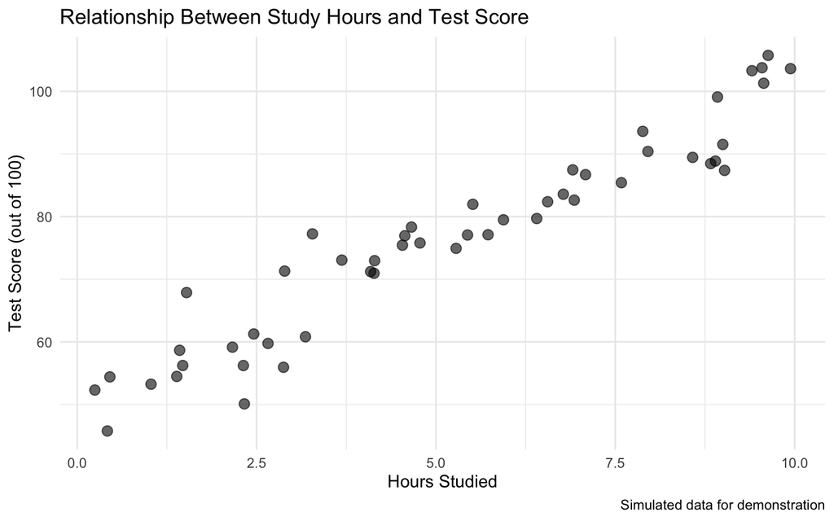

```r
ggplot(study_data, aes(x = hours_studied, y = test_score)) +
  geom_point(alpha = 0.6, size = 3) +
  labs(
    title = "Relationship Between Study Hours and Test Score",
    x = "Hours Studied",
    y = "Test Score (out of 100)",
    caption = "Simulated data for demonstration"
  ) +
  theme_minimal(base_size = 12)
```

**Observation**: There appears to be a positive linear relationship between hours studied and test scores.

### Calculate Correlation

```r
# Pearson correlation coefficient
cor_value <- cor(study_data$hours_studied, study_data$test_score)
cat("Correlation:", round(cor_value, 3))
```

```
## Correlation: 0.957
```

## Simple Linear Regression: Preview

Linear regression helps us: 1. Quantify the relationship between variables 2. Make predictions 3. Test hypotheses about relationships

The basic model:
$$Y = \beta_0 + \beta_1 X
+ \epsilon$$

Where: - $Y$ = response variable (test score) - $X$ = predictor variable (hours studied) - $\beta_0$ = intercept (expected score with 0 hours) - $\beta_1$ = slope (change in score per hour studied) - $\epsilon$ = random error

```r
# Fit a simple linear model
model <- lm(test_score ~ hours_studied, data = study_data)

# Tidy output using broom
tidy(model)
```

```
## # A tibble: 2 × 5
##   term          estimate std.error statistic  p.value
##   <chr>            <dbl>     <dbl>     <dbl>    <dbl>
## 1 (Intercept)      49.3      1.36       36.2 1.62e-36
## 2 hours_studied     5.19     0.228      22.7 2.36e-27
```

### Visualize the Fitted Line

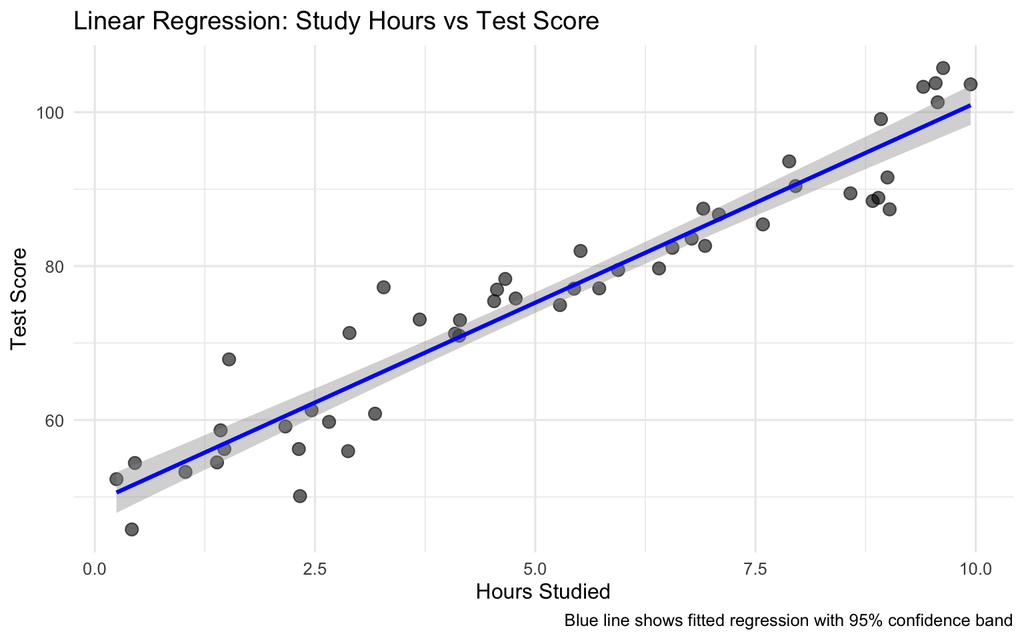

```r
ggplot(study_data, aes(x = hours_studied, y = test_score)) +
  geom_point(alpha = 0.6, size = 3) +
  geom_smooth(method = "lm", se = TRUE, color = "blue") +
  labs(
    title = "Linear Regression: Study Hours vs Test Score",
    x = "Hours Studied",
    y = "Test Score",
    caption = "Blue line shows fitted regression with 95% confidence band"
  ) +
  theme_minimal(base_size = 12)
```

## Reproducible Workflow Example

A typical reproducible analysis follows these steps:

```r
# 1. Load packages
library(tidyverse)

# 2. Import data
data <- read_csv("data/my_data.csv")

# 3. Explore data
glimpse(data)
summary(data)

# 4. Visualize
ggplot(data, aes(x = x, y = y)) +
  geom_point()

# 5. Fit model
model <- lm(y ~ x, data = data)

# 6. Check diagnostics
plot(model)

# 7. Summarize results
tidy(model)
glance(model)

# 8. Document session info
sessionInfo()
```

## Best Practices for This Course

1. **Always use R Markdown**: Integrate code, output, and narrative
2. **Comment your code**: Explain your reasoning
3. **Use meaningful names**: `test_score` not `x1`
4. **Follow tidyverse style**: Consistent, readable code
5. **Check your work**: Run code chunks frequently
6. **Document packages**: Include `sessionInfo()` at the end
7. **Save raw data**: Never overwrite original files
8. **Use relative paths**: Makes code portable

## Summary

Key concepts from this lecture:

- **Reproducibility** is essential for good science and efficient work
- **Tidyverse** provides a consistent framework for data analysis in R
- **R Markdown** integrates code and narrative for literate programming
- **Linear relationships** can be explored visually and quantified with correlation
- **Linear regression** models the relationship between variables

## Practice Exercises

1. Create your own simulated dataset with a negative relationship between variables
2. Calculate the correlation and visualize with a scatter plot
3. Fit a simple linear regression and interpret the slope
4. Document your entire analysis in an R Markdown document

## Next Steps

In the next lecture, we will: - Deep dive into data visualization with ggplot2 - Learn advanced exploratory data analysis techniques - Understand different types of variables and relationships

## References

- Fox, J. (2016). *Applied Regression Analysis and Generalized Linear Models* (3rd ed.). Sage Publications.
- Wickham, H., & Grolemund, G. (2017). *R for Data Science*. O’Reilly Media.
- Wickham, H. (2014). Tidy Data. *Journal of Statistical Software*, 59(10), 1-23.

**Course Repository**: github.com/crweber9874/linear_regression_class

**License**: CC BY-SA 4.0